# Validation of marker gene expression

Ally Hawkins

2025-02-24

This notebook looks at marker gene expression for consensus cell types in SCPCP000001. The marker genes shown in this notebook can be found in [`references/validation-markers.tsv`](https://github.com/AlexsLemonade/OpenScPCA-analysis/blob/main/analyses/cell-type-consensus/references/validation-markers.tsv).

All plots will also show the final cell type annotation group based on the `validation_group_annotation` in [`references/consensus-validation-groups.tsv`](https://github.com/AlexsLemonade/OpenScPCA-analysis/blob/main/analyses/cell-type-consensus/references/consensus-validation-groups.tsv). This means that cells assigned to more granular cell types will be lumped together with a broader cell type, e.g., memory T cell and naive T cell will be renamed as just T cell.

```r
suppressPackageStartupMessages({
  # load required packages
  library(ggplot2)
  library(patchwork)
})

# Set default ggplot theme
theme_set(
  theme_classic()
)
```

## Data setup

```r
# The base path for the OpenScPCA repository, found by its (hidden) .git directory
repository_base <- rprojroot::find_root(rprojroot::is_git_root)
module_base <- file.path(repository_base, "analyses", "cell-type-consensus")

# results directory with cell-type-consensus
results_dir <- file.path(module_base, "results", "cell-type-consensus", params$project_id)

# data directory where project metadata files live
data_dir <- file.path(repository_base, "data", "current")
```

```r
# marker_heatmap
plotting_functions <- file.path(module_base, "exploratory-notebooks", "utils", "plotting-functions.R")
source(plotting_functions)
```

```r
# get consensus results
consensus_results_files <- list.files(results_dir, pattern = "_consensus-cell-type-assignments\\.tsv.\\gz$", recursive = TRUE, full.names = TRUE)

# get gene expression files
gene_exp_files <- list.files(results_dir, pattern = "_marker-gene-expression\\.tsv.\\gz$", recursive = TRUE, full.names = TRUE)

# list of all validation markers
validation_markers_file <- file.path(module_base, "references", "validation-markers.tsv")

# all validation groups mapped to consensus labels
validation_groups_file <- file.path(module_base, "references", "consensus-validation-groups.tsv")
```

```r
# read in consensus and gene expression results
consensus_df <- consensus_results_files |>
  purrr::map(readr::read_tsv) |>
  dplyr::bind_rows()

gene_exp_df <- gene_exp_files |>
  purrr::map(readr::read_tsv) |>
  dplyr::bind_rows()

# read in validation markers
markers_df <- readr::read_tsv(validation_markers_file)

validation_groups_df <- readr::read_tsv(validation_groups_file) |>
  # rename final assigned group to avoid conflicts when merging in marker gene expression
  # we want to separate the marker gene group from the actual cell type annotation
  dplyr::select(consensus_annotation, broad_celltype_group = validation_group_annotation)
```

```r
# combine into one data frame that has all marker genes
# one row for each cell/marker gene combination (total rows= total cells x total marker genes)
# includes original consensus annotation, braod cell type group, marker gene id, logcounts, validation group annotation, information regarding expression of marker gene in CellMarker tissues
combined_df <- consensus_df |>
  # add in broad cell type group which is used for plotting
  # groups similar cell types together
  dplyr::left_join(validation_groups_df, by = c("consensus_annotation")) |>
  dplyr::left_join(gene_exp_df, by = c("barcodes", "library_id")) |>
  # add marker gene information (associated validation group annotation, gene observed count, percent tissues)
  # account for the same gene being present in multiple cell types
  dplyr::left_join(markers_df, by = c("ensembl_gene_id"), relationship = "many-to-many") |>
  dplyr::rowwise() |>
  dplyr::mutate(
    detected = logcounts > 0 # column indicating if gene is present or not
  )
```

## Plot setup

```r
# prep for plots
# get total number of cells per final annotation group
total_cells_df <- combined_df |>
  dplyr::select(library_id, barcodes, broad_celltype_group) |>
  unique() |>
  dplyr::count(broad_celltype_group, name = "total_cells")
```

```r
# table with one row per unique broad cell type/ marker gene combination
# first all cells in with the same broad_celltype_group (determined based on consensus_annotation) are grouped together
# then get the mean gene expression and total percentage of cells that express each marker gene across all cells in that group
# do this for every possible marker gene/ validation group assignment
# second we calculate the mean expression and mean percentage of all marker genes in a given validation group (this value is used only in the second section of the report)
group_stats_df <- combined_df |>
  # for each assigned cell type/marker gene combo get total detected and mean expression
  dplyr::group_by(broad_celltype_group, ensembl_gene_id) |>
  dplyr::summarize(
    detected_count = sum(detected),
    mean_exp = mean(logcounts)
  ) |>
  # add in validation group for marker genes
  # this includes all possible marker genes and all possible validation group assignments
  dplyr::left_join(markers_df, by = c("ensembl_gene_id"), relationship = "many-to-many") |>
  # now get the mean expression/ mean percentage across all marker genes for a given validation group
  # here the broad_celltype_group is the final assigned annotation for that group of cells
  # the validation_group_annotation refers to the cell type that marker gene is associated with
  dplyr::group_by(broad_celltype_group, validation_group_annotation) |>
  dplyr::mutate(
    # calculate mean expression/detected across all markers for a specific group
    all_markers_mean_exp = mean(mean_exp),
    all_markers_detected_count = mean(detected_count)
  ) |>  # add total cells
  dplyr::left_join(total_cells_df, by = c("broad_celltype_group")) |>
  # for plotting we're only going to look at any cell types with > 50 cells otherwise these plots can get wild
  dplyr::filter(total_cells > 50) |>
  dplyr::rowwise() |>
  dplyr::mutate(
    # get total percent expressed
    percent_exp = (detected_count/total_cells) * 100,
    all_markers_percent_exp = (all_markers_detected_count/total_cells) * 100,
    # account for NA/unknowns and set axes order
    broad_celltype_group = tidyr::replace_na(broad_celltype_group, "unknown") |>
      factor(levels =  c(unique(markers_df$validation_group_annotation), "unknown"))
  )
# make a data frame that just has the unique genes
# unique genes are those that are only observed in one cell type based on observance in Cell Marker
# this was determined when creating the marker gene table from Cell Marker
unique_gene_df <- group_stats_df |>
  dplyr::filter(gene_observed_count == 1)
```

```r
# get list of celltypes to keep and assign colors
celltype_groups <- group_stats_df |>
  dplyr::pull(broad_celltype_group) |>
  unique() |>
  as.character()

# assign colors to use in annotation bars
celltype_colors <- palette.colors(palette = "alphabet")[1:length(celltype_groups)]
names(celltype_colors) <- celltype_groups
```

## Expression of unique marker genes

First we will look at the expression of marker genes that are specific to a cell type group.  
All marker genes shown in the following plots are only found to be a marker gene for a single cell type group. Only cell type groups with at least 50 cells will be shown.

Note that I did try and look at all marker genes, without specifying that they must be unique, and the plots were overwhelming with lots of genes. Instead I included the a separate section looking at the mean expression across all markers for a given group.

### Dot plot

The dot plot shows the mean expression of each marker gene across all cells assigned to a given cell type group. Only genes that have mean expression > 0 and are expressed in at least 5% of cells in at least one cell type group will be shown.

```r
# filter markers to those that are actually relevant
# we will only plot the marker genes for cell types that are part of the assigned broad validation group for this project
# we don't care about plotting marker genes for cell types that aren't present here
# note that we will use this for both the dotplot and the heatmap
filtered_markers_df <- markers_df |>
  dplyr::filter(validation_group_annotation %in% celltype_groups,
                gene_symbol %in% group_stats_df$gene_symbol)

# now only keep unique markers for the dotplot
unique_markers_df <- filtered_markers_df |>
  dplyr::filter(gene_observed_count == 1)

# specify x axis order for dotplot
marker_gene_order <- unique_markers_df |>
  dplyr::pull(gene_symbol)

# set order for cell types
celltype_order <- unique(unique_markers_df$validation_group_annotation)
```

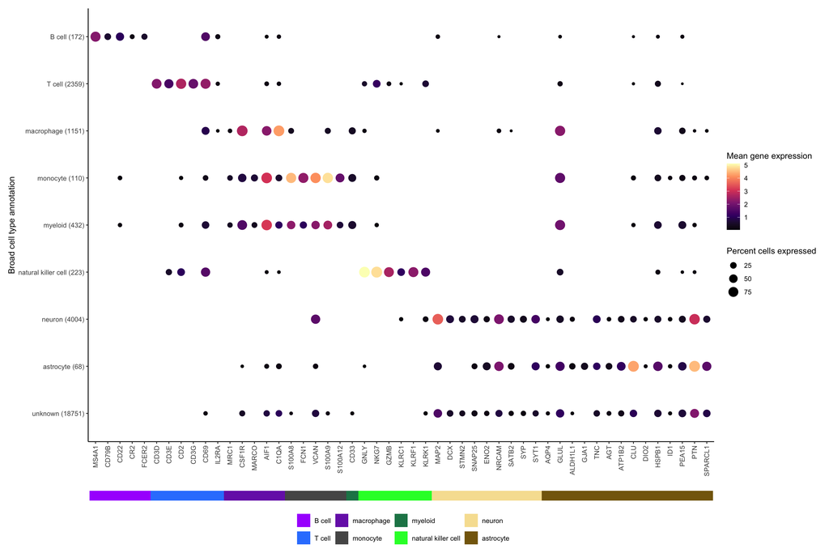

```r
# filter out low expressed genes
dotplot_df <- unique_gene_df |>
  dplyr::filter(mean_exp > 0, percent_exp > 5) |>
  dplyr::arrange(broad_celltype_group) |>
  # add a label for the plot
  dplyr::mutate(y_label = as.factor(glue::glue("{broad_celltype_group} ({total_cells})"))) |>
  # remove marker genes that aren't present in final annotations and set x axis order
  dplyr::filter(gene_symbol %in% marker_gene_order) |>
  dplyr::mutate(
    # set orders of gene symbol and validation groups
    gene_symbol = factor(gene_symbol, levels = marker_gene_order),
    validation_group_annotation = factor(validation_group_annotation, levels = celltype_order)
  )

# make dotplot with marker gene exp
dotplot <- ggplot(dotplot_df, aes(y = forcats::fct_rev(y_label), x = gene_symbol, color = mean_exp, size = percent_exp)) +
  geom_point() +
  scale_color_viridis_c(option = "magma") +
  theme(
    axis.text.x = element_text(angle = 90, hjust = 1, vjust = 0.5)
  ) +
  labs(
    x = "",
    y = "Broad cell type annotation",
    color = "Mean gene expression",
    size = "Percent cells expressed"
  )


# add annotation bar aligning marker genes with validation group
color_bar <- ggplot(dotplot_df, aes(x = gene_symbol, y = 1, fill = validation_group_annotation)) +
  geom_tile() +
  scale_fill_manual(values = celltype_colors, breaks = levels(dotplot_df$validation_group_annotation)) +
  ggmap::theme_nothing() +
  theme(legend.position = "bottom") +
  labs(fill = "")

dotplot + color_bar +
  patchwork::plot_layout(ncol = 1, heights = c(4, 0.1))
```

### Heatmap

The heatmap shows the mean expression of each marker gene across all cells assigned to a given cell type group. In contrast to the dot plot, we will show all marker genes for a given cell type group, not just the uniquely expressed genes.

```r
# add column to uniquely label gene symbols since some genes are present across multiple cell types
# add this here since we will use the order in this data frame to set the order of the heatmap columns
heatmap_markers_df <- filtered_markers_df |>
  dplyr::mutate(
    unique_symbol = glue::glue("{gene_symbol}-{validation_group_annotation}")
  )
```

```r
# first make a mtx to use for the heatmap with rows as cell types and genes as columns
heatmap_mtx <- group_stats_df |>
  dplyr::ungroup() |>
  # add unique label for gene symbol
  dplyr::mutate(
    unique_symbol = glue::glue("{gene_symbol}-{validation_group_annotation}")
  ) |>
  dplyr::select(unique_symbol, broad_celltype_group, mean_exp) |>
  dplyr::filter(unique_symbol %in% heatmap_markers_df$unique_symbol) |>
  tidyr::pivot_wider(
    names_from = unique_symbol,
    values_from = mean_exp
  ) |>
  tibble::column_to_rownames("broad_celltype_group") |>
  as.matrix()
# make sure cell types are present in the right order
heatmap_mtx <- heatmap_mtx[c(celltype_order, "unknown"), heatmap_markers_df$unique_symbol]

# create annotation for heatmap
annotation <- ComplexHeatmap::columnAnnotation(
  group = heatmap_markers_df$validation_group_annotation,
  col = list(
    group = celltype_colors
  ),
  annotation_legend_param = list(
      title = "Validation group"
    )
)
```

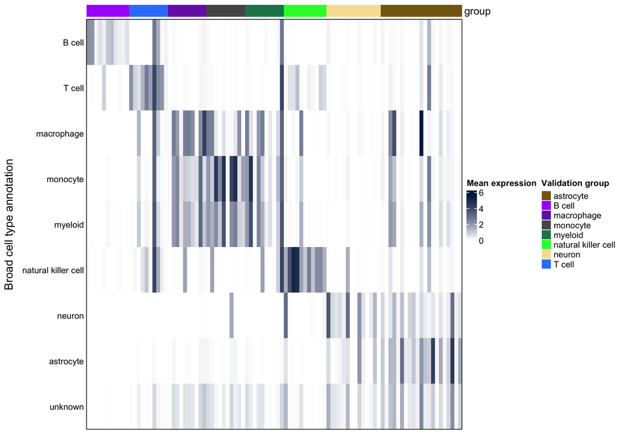

```r
marker_gene_heatmap(heatmap_mtx, annotation)
```

## Mean expression across all marker genes

We will make the same dot plot but instead of looking at the expression of individual marker genes for all cell type groups, we will plot the mean expression of all marker genes for a specific cell type group.

This is calculated by first getting the mean expression of each individual marker gene across all cells in a cell type group and then taking the mean of that value across all marker genes. This results in one row per assigned cell type group and one column per marker gene group.

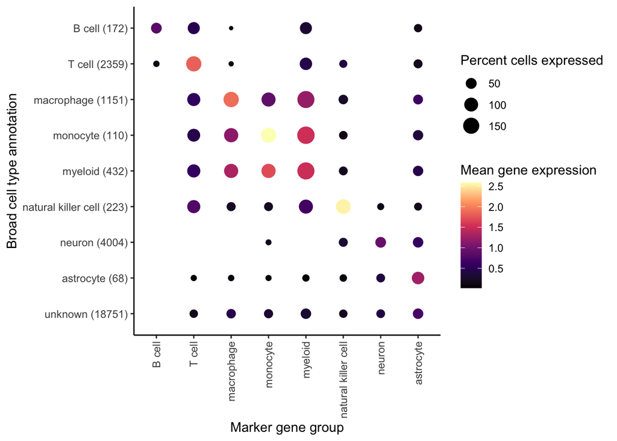

```r
# filter low expressed genes
grouped_dotplot_df <- group_stats_df |>
  dplyr::select(broad_celltype_group, validation_group_annotation, all_markers_mean_exp, all_markers_percent_exp, total_cells) |>
  unique() |>
  dplyr::filter(all_markers_mean_exp > 0, all_markers_percent_exp > 5, validation_group_annotation %in% celltype_groups) |>
  dplyr::arrange(broad_celltype_group) |>
  # make sure labels are correct
  dplyr::mutate(y_label = as.factor(glue::glue("{broad_celltype_group} ({total_cells})")),
                validation_group_annotation = factor(validation_group_annotation, levels = celltype_order))


ggplot(grouped_dotplot_df, aes(y = forcats::fct_rev(y_label), x = validation_group_annotation, color = all_markers_mean_exp, size = all_markers_percent_exp)) +
  geom_point() +
  scale_color_viridis_c(option = "magma") +
  theme(
    axis.text.x = element_text(angle = 90, hjust = 1, vjust = 0.5)
  ) +
  labs(
    x = "Marker gene group",
    y = "Broad cell type annotation",
    color = "Mean gene expression",
    size = "Percent cells expressed"
  )
```

## Conclusions

- Regardless of looking at individual genes or the mean expression of all genes, we see similar patterns where generally the cells assigned to a given cell type show expression of the appropriate marker genes when compared to other cells.
- There seems to be pretty clear distinction of T cells, B cells, and NK cells.
- Monocytes, macrophages, and myeloid cells are generally hard to distinguish from each other and all share similar marker genes. Perhaps we could collapse these into myeloid, but I do see expression of monocyte specific genes in monocytes only and maybe some macrophage specific genes in macrophages only, so it’s probably okay to keep separate. I think that is more obvious in the heatmaps than in the dot plots.
- Neurons and astrocytes both show expression of both neuron and astrocyte marker genes. It does look like there are a set of genes that are more highly expressed in the astrocyte population though, so I think we can keep those gene sets separate.
- Here the unknown cells don’t show strong expression of any specific set of genes, but it does look like they show more expression of neuron/astrocyte markers than any of the other marker genes in the plot. This makes sense since we are looking at brain tumors and I expect similarity between tumor cells and neural cell types.